# HOBIC FISH Data Processing

Extracting 5-species depth profiles from 4-channel fluorescence images

## Summary

We processed confocal FISH images from the Heine 2025 HOBIC flow-chamber experiment to construct **depth-resolved 5-species composition profiles** as input to the reaction–diffusion PDE fit.

- Input: Leica confocal **FISH `.lif`** (CH / DH conditions, Ti substrate)
- Challenge: only **4** detector channels for **5** target species
- Approach: decode the paper’s labelling design via per-voxel colocalization
- Output: **depth × 5-species composition profiles** and PDE fit results (*D*<sub>*i*</sub>, *u*)

New: `fish_decode.py`, `lif_quicklook.py`; updated: `lif_to_zprofiles.py`

## Input data: HOBIC FISH `.lif` (11 files total)

| Experiment batch | Cond. | Day | Substrate |
| --- | --- | --- | --- |
| 220518/601/720, 220817, 240416 | CH | 1, 6, 10, 15, 21 | Ti |
| 241203 (Tag1) | DH | 1 | Ti |
| 241018 | DH | 6, 10, 15, 21 | Ti + Glass |

- Pixel size 0.18 µm, z-step 2 µm. Only Ti substrate used for analysis (HOBIC = titanium implant model; 9 Glass FOVs excluded, retained for separate analysis).
- Headless environment: no GUI tools (Fiji / napari). Files read with `readlif`; PNGs exported with Times font and µm scale bar.

## Raw 4-channel images

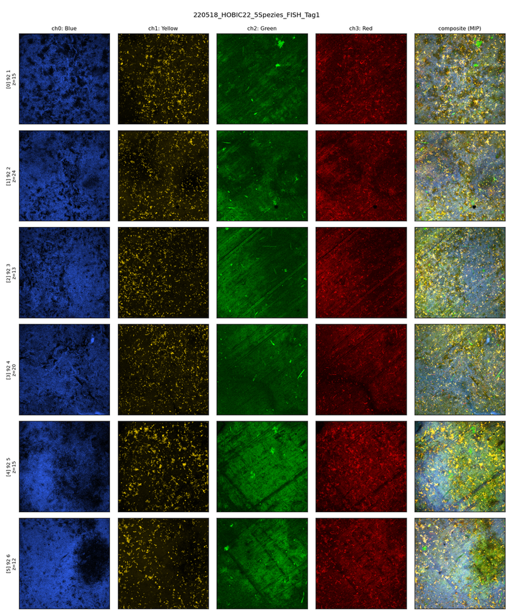

rows = FOVs, columns = Blue / Yellow / Green / Red + composite

## Mismatch between channels and species

Four detector channels cover five target species; a one-to-one colour–species mapping does not hold.

From Heine 2025 (*Front. Oral Health*, Table S5 + Methods §2.6):

> *F. nucleatum was targeted by two probes … labeled with different dyes – resulting in co-localized blue and red fluorescence.*

*F. nucleatum* alone carries dual labels (Alexa405 = blue, Alexa647 = red) and therefore produces signal in both channels.

## Decoding rule (colocalization)

| Channel | Contributing species |
| --- | --- |
| **Blue** 405 nm | *S. oralis* + *F. nucleatum* |
| **Green** 488 nm | *A. naeslundii* |
| **Yellow** 552 nm | *V. dispar/parvula* |
| **Red** 638 nm | *P. gingivalis* + *F. nucleatum* |

*F*<sub>*n*</sub> = *B* ∩ *R*, *S*<sub>*o*</sub> = *B* − *F*<sub>*n*</sub>, *P*<sub>*g*</sub> = *R* − *F*<sub>*n*</sub>

Colocalization is computed per voxel before taking the xy-average ($mean(min) ≠ min (mean)$).

## Decoded 5 species

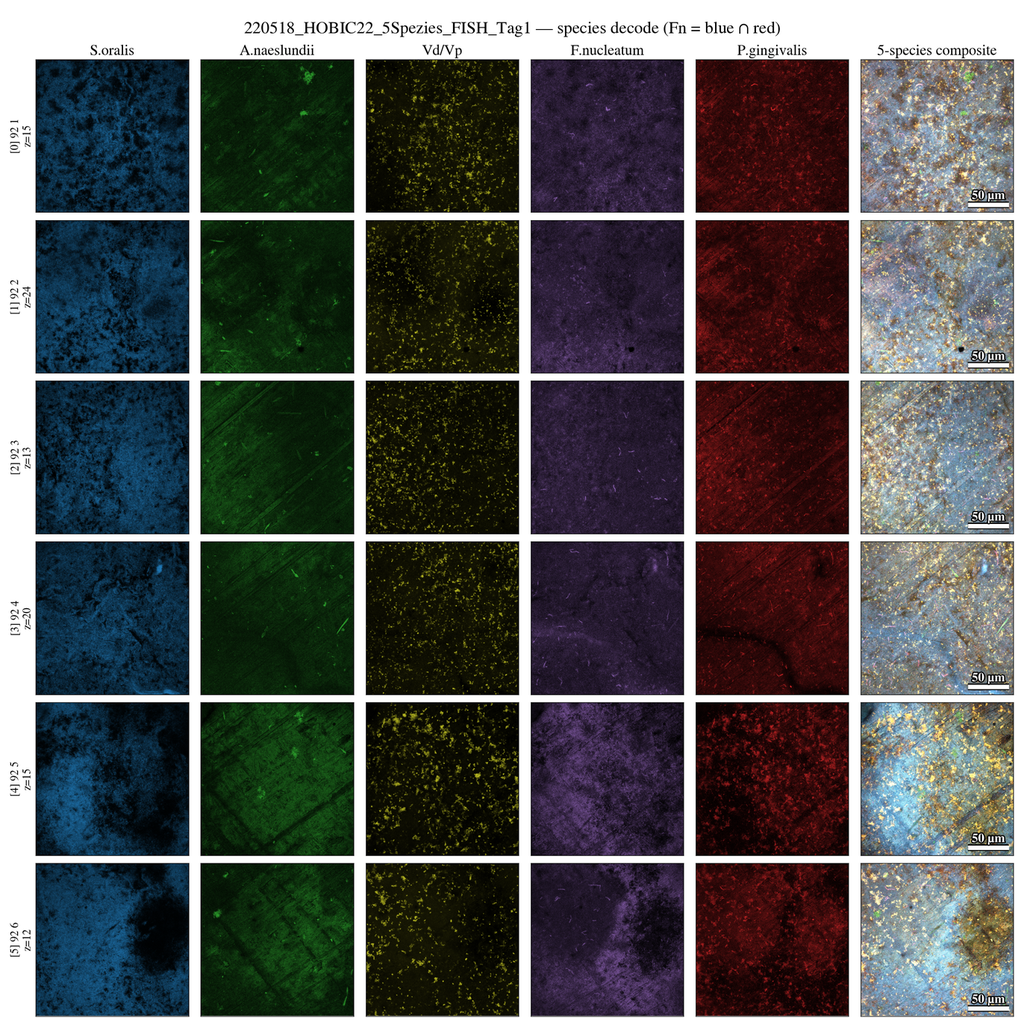

*F. nucleatum* (purple) is cleanly separated from *S. oralis* / *P. gingivalis*.

## Decoding error in the original code and the fix

The original code assumed “blue = pure *S. oralis* / red = pure *P. gingivalis* / purple = *F. nucleatum*.” No purple channel exists in the actual files; without correction:

- *F. nucleatum* signal is lost entirely
- *S. oralis* and *P. gingivalis* counts are inflated by *F. nucleatum* bleed-in

This affects 3 of the 5 species fed into the spatial PDE. A canonical decoder `fish_decode.py` was implemented and is shared by both pipeline tools.

## Profile extraction, merging, and naming conventions

**z-profile**: each FOV’s 3-D stack is reduced to an xy-mean intensity per depth slice.

**Replicate merging**: multiple `.lif` files sharing the same `(condition, day)` are pooled (Day 1 = 3 separate experiment dates, 15 FOVs total, averaged once).

**Experimental naming conventions** (Heine, e-mail 2026-05-26) encoded in the tool:

- HOBIC22 = commensal → **CH**; HOBIC24 = dysbiotic → **DH** (resolved automatically)
- Day number: filename suffix `TagN`; for HOBIC24, leading integer of the series name
- **Substrate filter** `--substrate ti`: selects Ti from mixed Ti/Glass datasets

```bash
python scripts/pde/lif_to_zprofiles.py "HOBIC FISH"/*.lif --substrate ti
```

## Result: CH / DH depth time-series (Ti)

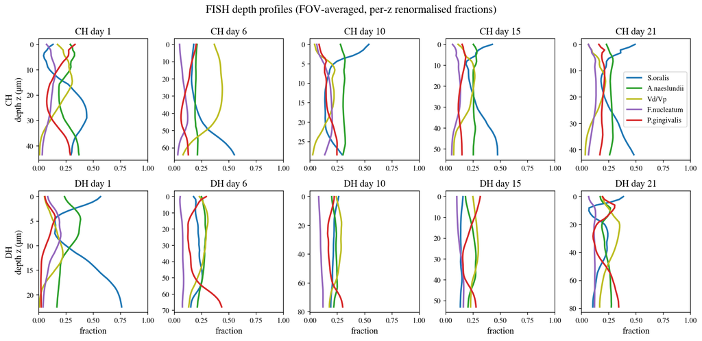

## CH vs DH comparison (deep *P. gingivalis*)

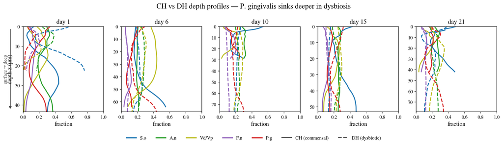

**Solid = CH, dashed = DH**; colour = species, y-axis = µm (surface → deep). From day 6 onward, the *P. gingivalis* (red) centre of mass is consistently deeper in DH than in CH.

## Per-depth composition (stacked area)

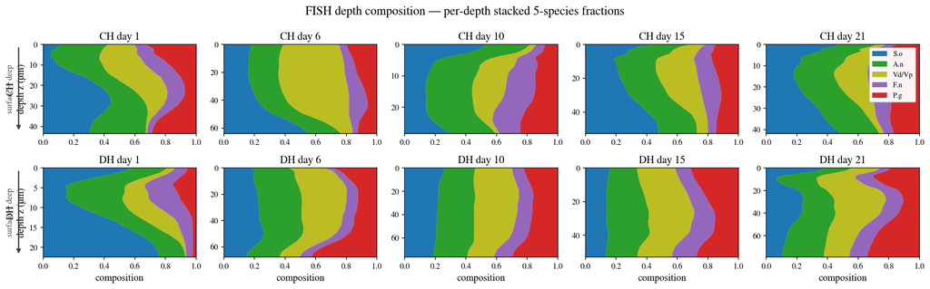

Each depth’s 5-species fractions are stacked to unity. The expanded *P. gingivalis* (red) band in the deep layers of the DH condition is apparent across late time points.

## Reaction–diffusion PDE fit

Compositional dynamics are decomposed into ecological interactions and spatial transport:

1. **Reaction** (*A*, *b*): species interaction matrix. **Fixed** (gLV / TMCMC estimate)
2. **Diffusion** *D*<sub>*i*</sub> **+ advection** *u*: depth-wise transport. **Fit target**

∂<sub>*t*</sub>*φ*<sub>*i*</sub> = *D*<sub>*i*</sub> ∂<sub>*z**z*</sub>*φ*<sub>*i*</sub> − *u* ∂<sub>*z*</sub>*φ*<sub>*i*</sub> + *φ*<sub>*i*</sub> [(*A**φ*+*b*)<sub>*i*</sub>−*φ*<sup>⊤</sup>(*A**φ*+*b*)]

*D*<sub>*i*</sub> and *u* are optimised by L-BFGS to minimise MSE against the observed profiles. Runs executed on the HPC (PBS), CH and DH separately (Ti, *N*<sub>*z*</sub> = 48, 8 restarts).

## Fit results: diffusion coefficients *D*<sub>*i*</sub> and advection *u*

| Species | *D*<sup>CH</sup> | *D*<sup>DH</sup> |
| --- | --- | --- |
| *S. oralis* | 0.029 | 0.015 |
| *A. naeslundii* | 0.006 | 0.006 |
| *Vd/Vp* | 0.005 | 0.009 |
| *F. nucleatum* | 0.006 | 0.015 |
| *P. gingivalis* | 0.006 | 0.006 |

Advection: *u*<sup>CH</sup> = 0.0069, *u*<sup>DH</sup> = 0.0059 (units: µm/s-equivalent)

DH: `success=True` (converged); CH: `success=False` (not converged, preliminary). Results stored in `D_fit_*_nz48_eps3e-4.json`.

## Fit result: CH condition

[figure not shown]

Observed profiles (dots) vs PDE prediction (lines). CH, *N*<sub>*z*</sub> = 48, loss = 0.125.

## Fit result: DH condition

[figure not shown]

Observed profiles (dots) vs PDE prediction (lines). DH, *N*<sub>*z*</sub> = 48, loss = 0.154 (converged).

## Finding: deep accumulation of *P. gingivalis* in dysbiosis

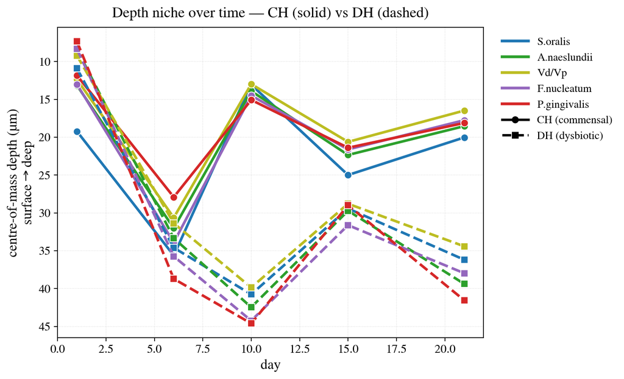

- *P. gingivalis* migrates to deeper layers in DH from day 6 (centre-of-mass shift up to +30 µm, consistent with the anaerobic niche)
- *F. nucleatum*–*P. gingivalis* co-localisation is restricted to the early stage (DH day 1: coloc = 0.76); from day 6 onward CH > DH, indicating that *P. gingivalis* separates from *F. nucleatum* and accumulates independently
- CH / DH community divergence is ~0.2 from day 1 and remains approximately constant

## Deliverables and data limitations

| File | Role |
| --- | --- |
| `fish_decode.py` | New · canonical decoder (*F*<sub>*n*</sub> = *B* ∩ *R*) |
| `scripts/pde/lif_quicklook.py` | New · visualiser (Times font, µm bar) |
| `scripts/pde/lif_to_zprofiles.py` | Updated · decode + merge + naming + substrate filter |
| `zprofiles_all_ti.csv` | PDE input (depth × species × condition) |
| `D_fit_*_nz48_eps3e-4.json` | Fit results (*D*<sub>*i*</sub>, *u*) |

**Data limitations**: HOBIC origin limits analysis to **CH / DH only** (static conditions CS/DS unavailable). Glass FOVs from batch 241018 (DH) are excluded. DH late time points (Day 15/21) have only 2 Ti FOVs, which reduces the precision of the late-stage estimates.